# Práctica 1 - Técnicas de Machine Learning

Roberto Bonilla Ibarra

2023-03-17

# Redes neuronales para regresión

En este trabajo desarrollaremos un trabajo de regresión para predecir el **costo del seguro de gastos médicos** de acuerdo a las siguientes variables.

Necesitaremos los siguientes paquetes

```r
# Borramos
rm(list = ls())

# Paquetes
shhh <- suppressPackageStartupMessages
library(skimr) # resumen numérico
library(dplyr) # depuración datos
library(tidyverse) # depuración datos
```

```r
library(ggthemes) # tema para graficar
library(corrplot) # tema para graficar matriz de correlaciones
library(fastDummies) # Creación de Dummies
library(corrr) # Crear correlaciones
library(Hmisc) # Creación de histogramas
library(parallel) # Librerías de Cómputo en Paralelo
library(doParallel) # Librerías de Cómputo en Paralelo
```

## Análisis exploratorio de datos.

Primero comenzaremos explorando los estadísticos básicos del set de datos y su distribución:

```r
insurance<- read_csv("C:\\Users\\Hp\\Documents\\UCM\\TML\\Trabajo\\Práctica 1\\insurance.csv",show_col_types = FALSE)
insurance
```

| age | sex | bmi | children | smoker | region | charges |
| --- | --- | --- | --- | --- | --- | --- |
| 19 | female | 27.900 | 0 | yes | southwest | 16884.924 |
| 18 | male | 33.770 | 1 | no | southeast | 1725.552 |
| 28 | male | 33.000 | 3 | no | southeast | 4449.462 |
| 33 | male | 22.705 | 0 | no | northwest | 21984.471 |
| 32 | male | 28.880 | 0 | no | northwest | 3866.855 |
| 31 | female | 25.740 | 0 | no | southeast | 3756.622 |
| 46 | female | 33.440 | 1 | no | southeast | 8240.590 |
| 37 | female | 27.740 | 3 | no | northwest | 7281.506 |
| 37 | male | 29.830 | 2 | no | northeast | 6406.411 |
| 60 | female | 25.840 | 0 | no | northwest | 28923.137 |

[output cut: 1328 more lines]

Usando la función `skim()`

```r
insurance |> skim()
```

Data summary

| Name | insurance |
| --- | --- |
| Number of rows | 1338 |
| Number of columns | 7 |
| _______________________ |  |
| Column type frequency: |  |
| character | 3 |
| numeric | 4 |
| ________________________ |  |
| Group variables | None |

**Variable type: character**

| skim_variable | n_missing | complete_rate | min | max | empty | n_unique | whitespace |
| --- | --- | --- | --- | --- | --- | --- | --- |
| sex | 0 | 1 | 4 | 6 | 0 | 2 | 0 |
| smoker | 0 | 1 | 2 | 3 | 0 | 2 | 0 |
| region | 0 | 1 | 9 | 9 | 0 | 4 | 0 |

**Variable type: numeric**

| skim_variable | n_missing | complete_rate | mean | sd | p0 | p25 | p50 | p75 | p100 | hist |
| --- | --- | --- | --- | --- | --- | --- | --- | --- | --- | --- |
| age | 0 | 1 | 39.21 | 14.05 | 18.00 | 27.00 | 39.00 | 51.00 | 64.00 | ▇▅▅▆▆ |
| bmi | 0 | 1 | 30.66 | 6.10 | 15.96 | 26.30 | 30.40 | 34.69 | 53.13 | ▂▇▇▂▁ |
| children | 0 | 1 | 1.09 | 1.21 | 0.00 | 0.00 | 1.00 | 2.00 | 5.00 | ▇▂▂▁▁ |
| charges | 0 | 1 | 13270.42 | 12110.01 | 1121.87 | 4740.29 | 9382.03 | 16639.91 | 63770.43 | ▇▂▁▁▁ |

Podemos ver que en nuestro set de datos cibtanis con una variable objetivo denominado *charges*, tres variables numéricas y 3 variables categóricas.

Ahora veamos la distribución de las variables categóricas:

```r
# Revisando variable sex
insurance |>   count(sex, sort = TRUE) |>
  mutate(porc = 100*n/sum(n), cumsum(porc))
```

| sex | n | porc | cumsum(porc) |
| --- | --- | --- | --- |
| male | 676 | 50.52317 | 50.52317 |
| female | 662 | 49.47683 | 100.00000 |

Podemos ver que la variable sexo se encuentra balanceada entre femenino y masculino.

```r
# Revisando variable smoker
insurance |>   count(smoker, sort = TRUE) |>
  mutate(porc = 100*n/sum(n), cumsum(porc))
```

| smoker | n | porc | cumsum(porc) |
| --- | --- | --- | --- |
| no | 1064 | 79.52167 | 79.52167 |
| yes | 274 | 20.47833 | 100.00000 |

Podemos ver que la mayor parte de las personas aseguradas no son fumadores.

```r
# Revisando variable region
insurance |>   count(region, sort = TRUE) |>
  mutate(porc = 100*n/sum(n), cumsum(porc))
```

| region | n | porc | cumsum(porc) |
| --- | --- | --- | --- |
| southeast | 364 | 27.20478 | 27.20478 |
| northwest | 325 | 24.28999 | 51.49477 |
| southwest | 325 | 24.28999 | 75.78475 |
| northeast | 324 | 24.21525 | 100.00000 |

Podemos ver que la variable región prácticamente se encuentra balanceada, sin necesidad de alguna agrupación en sus clases.

Ahora veamos la distribución de las variables numéricas:

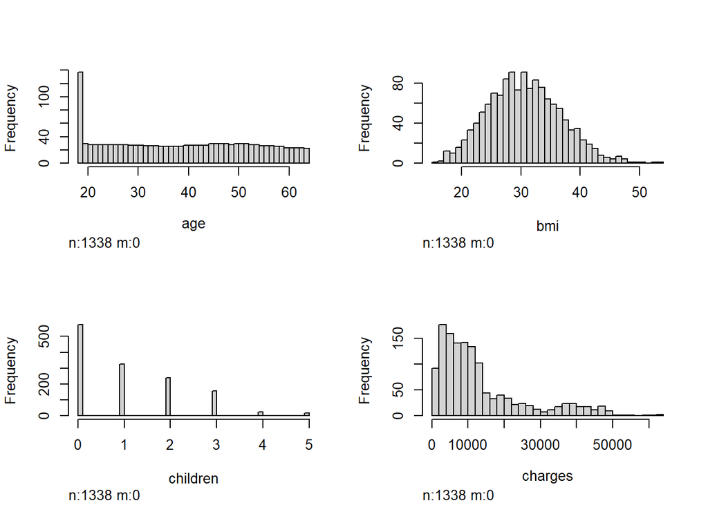

```r
hist.data.frame(insurance %>% dplyr::select(where(is.numeric)))
```

También procederemos a transformar la edad a *buckets* de 10 años.

```r
insurance <- insurance %>%
  mutate(age_bucket = cut(age, breaks = seq(15, 65, by = 10),
                          labels = gsub(" ", "",paste(seq(15, 55, by = 10), "_", seq(25, 65, by = 10))),
                          include.lowest = TRUE))
```

Ahora analizemos su distribución:

```r
# Revisando variable region
insurance |>   count(age_bucket, sort = TRUE) |>
  mutate(porc = 100*n/sum(n), cumsum(porc))
```

| age_bucket | n | porc | cumsum(porc) |
| --- | --- | --- | --- |
| 15_25 | 306 | 22.86996 | 22.86996 |
| 45_55 | 284 | 21.22571 | 44.09567 |
| 25_35 | 268 | 20.02990 | 64.12556 |
| 35_45 | 264 | 19.73094 | 83.85650 |
| 55_65 | 216 | 16.14350 | 100.00000 |

Podemos ver que la muestra cuenta con edades bastante balanceadas, siendo el menor grupo el de la gente mayor.

### Visualización de datos

Procederemos a analizar el factor de los fumadores y las regiones donde viven en el costo del seguro de gastos médicos:

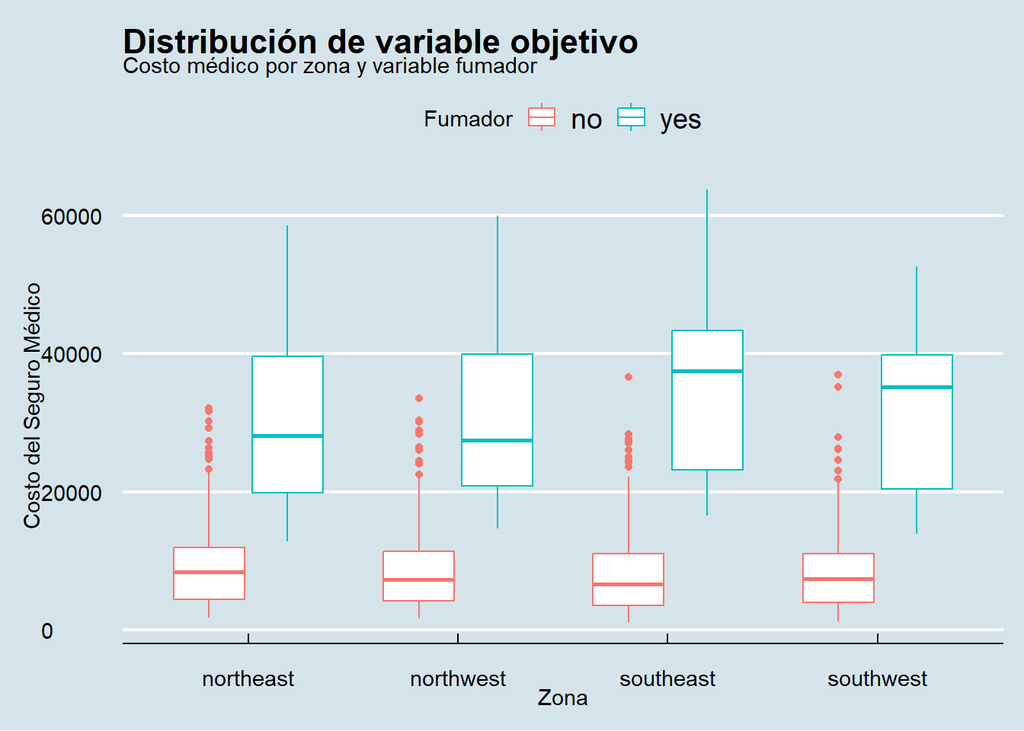

```r
ggplot(insurance, aes(x = factor(region), y = charges, color=factor(smoker))) +
  geom_boxplot() +
   labs(title = "Distribución de variable objetivo",
       subtitle = "Costo médico por zona y variable fumador",
       x = "Zona", y = "Costo del Seguro Médico", color= "Fumador") +
  theme_economist()
```

Podemos ver que la zona realmente no es significativa en comparación de la variable que nos permite identificar si el asegurado es o no fumador.

Ahora analizemos el impacto de la edad del asegurado y el sexo con respecto al costo del seguro.

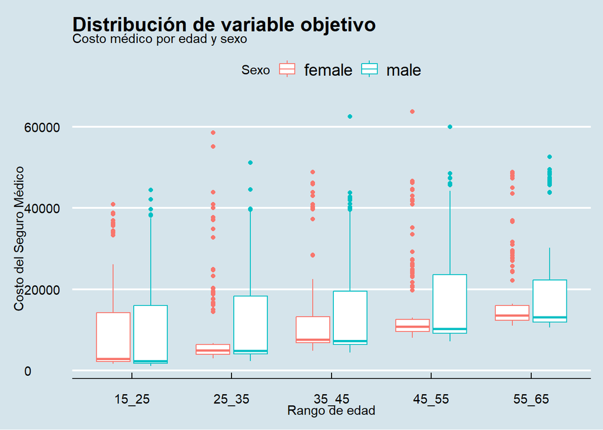

```r
ggplot(insurance, aes(x = factor(age_bucket), y = charges,color=factor(sex))) +
  geom_boxplot() +
   labs(title = "Distribución de variable objetivo",
       subtitle = "Costo médico por edad y sexo",
       x = "Rango de edad", y = "Costo del Seguro Médico", color= "Sexo") +
  theme_economist()
```

Podemos ver que existe un incremento de costo paulatino conforme cada rango de edades y que el sexo masculino tiende a tener costos mayores.

Ahora procederemos a medir el impacto del Índice de Masa Corporal, recordando lo siguiente:

- Si el IMC es menor a 18.4, el rango se denomina como peso insuficiente.
- Si el IMC se encuentra entre 18.5 y 24.9, se encuentra dentro del rango de peso normal.
- Si el IMC es entre 25.0 y 29.9, se encuentra dentro del rango de sobrepeso.
- Si el IMC es mayor o igual a 30 se considera obesidad.

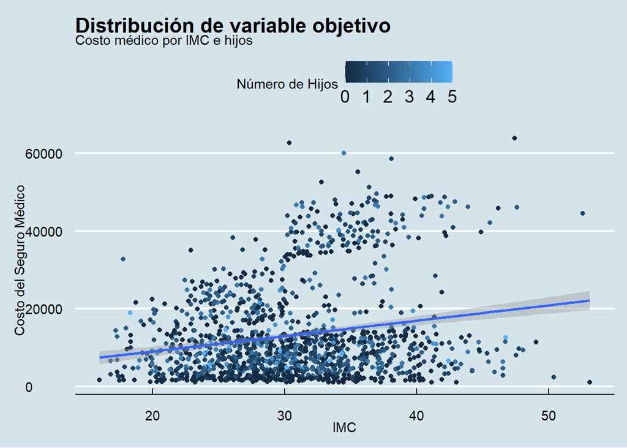

```r
ggplot(insurance, aes(x = bmi, y = charges)) +
  geom_point(aes(color=children))+
  geom_smooth(formula = y ~ x, method = "lm")+
   labs(title = "Distribución de variable objetivo",
       subtitle = "Costo médico por IMC e hijos",
       x = "IMC", y = "Costo del Seguro Médico", color= "Número de Hijos") +
  theme_economist()
```

Podemos ver entre más alto sea el IMC, mayor es el costo del seguro médico.

Por último procederemos con la matriz de correlación:

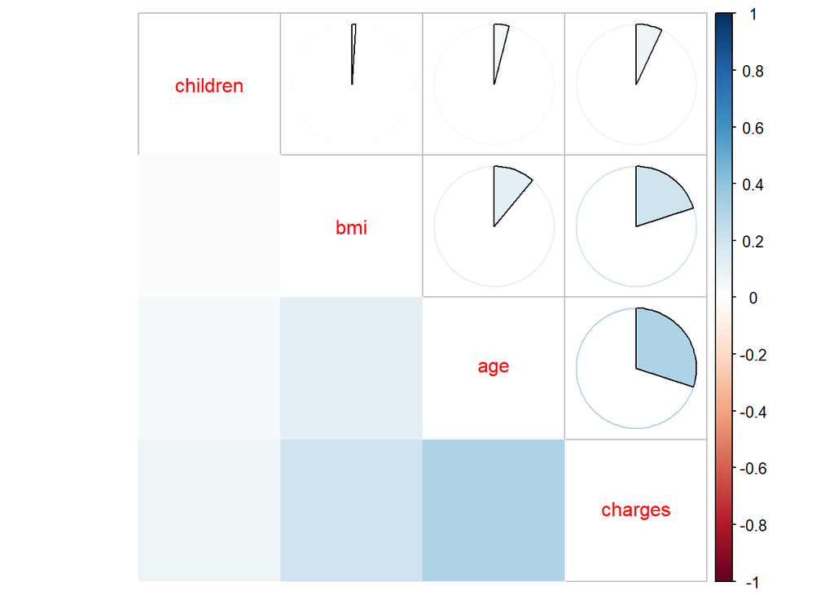

```r
cor_matrix <- insurance |> dplyr::select(where(is.numeric)) |> cor() |> round(2)

cor_matrix |>
  corrplot.mixed( lower = 'shade', upper = 'pie', order = 'hclust')
```

Donde la edad es la variable numérica más relacionada con el costo del seguro médico.

## Depuración de datos

Antes de proceder con la transformación de variables es importante analizar con más profundidad la variable objetivo.

El primer paso vamos a crear el Zscore de la variable charges y filtrar los registros que se encuentren con valores mayores a 3:

```r
insurance %>% mutate(zscore = (charges - mean(charges))/sd(charges)) %>% filter(zscore>3)
```

| age | sex | bmi | children | smoker | region | charges | age_bucket | zscore |
| --- | --- | --- | --- | --- | --- | --- | --- | --- |
| 28 | male | 36.400 | 1 | yes | southwest | 51194.56 | 25_35 | 3.131635 |
| 54 | female | 47.410 | 0 | yes | southeast | 63770.43 | 45_55 | 4.170104 |
| 31 | female | 38.095 | 1 | yes | northeast | 58571.07 | 25_35 | 3.740761 |
| 33 | female | 35.530 | 0 | yes | northwest | 55135.40 | 25_35 | 3.457055 |
| 60 | male | 32.800 | 0 | yes | southwest | 52590.83 | 55_65 | 3.246934 |
| 52 | male | 34.485 | 3 | yes | northwest | 60021.40 | 45_55 | 3.860523 |
| 45 | male | 30.360 | 0 | yes | southeast | 62592.87 | 35_45 | 4.072866 |

Podemos ver que tenemos 7 registros con cargos excesivos de seguro de gastos médicos. Para corregir este fenómeno procederemos a aplicar la raíz cuadrada de la variable:

```r
insurance <- insurance %>% mutate(charges_sqr = sqrt(charges))
```

Y procederemos a volver a revisar el Z-score de la variable:

```r
insurance %>%  mutate(zscore = (charges_sqr - mean(charges_sqr))/sd(charges_sqr)) %>% filter(zscore>3)
```

| age | sex | bmi | children | smoker | region | charges | age_bucket | charges_sqr | zscore |
| --- | --- | --- | --- | --- | --- | --- | --- | --- | --- |
| 54 | female | 47.41 | 0 | yes | southeast | 63770.43 | 45_55 | 252.5281 | 3.091735 |
| 45 | male | 30.36 | 0 | yes | southeast | 62592.87 | 35_45 | 250.1857 | 3.042701 |

Podemos ver que todavía existen dos registros, sin embargo, se encuentran muy cerca de 3 unidades, por lo tanto, podemos estar seguros que la variable ha sido corregida.

## Codificación y normalizació de variables

En este apartado del trabajo procederemos a dummyficar las variables categóricas, cuidando la multicolinealidad de las variables (removiendo la primer columna que se genera) con la librería *fastDummies*.

```r
dummyfied_data <- fastDummies::dummy_cols(insurance, remove_first_dummy = TRUE, select_columns = c("sex","smoker","region","age_bucket"))
```

Una vez transformado el set de datos, procederemos a reducir las variables a las que serán usadas en los procesos siguientes:

```r
model_data <- dummyfied_data %>% dplyr::select(-c("sex","smoker","region","age","charges","age_bucket"))
```

Una vez que se encuentren dummyficadas las variables, procederemos a normalizarlas:

```r
model_data  <- model_data  %>%
  dplyr::mutate(across(c(bmi, children), ~ (. - mean(.)) / sd(.)))
```

## Selección de variables

Primero procederemos identificando las variables dependientes e independientes:

```r
dput(names(model_data))
```

```
## c("bmi", "children", "charges_sqr", "sex_male", "smoker_yes",
## "region_northwest", "region_southeast", "region_southwest", "age_bucket_25_35",
## "age_bucket_35_45", "age_bucket_45_55", "age_bucket_55_65")
```

```r
variable_dep = c("charges_sqr")
variable_indepe = c("bmi", "children", "sex_male", "smoker_yes",
"region_northwest", "region_southeast", "region_southwest", "age_bucket_25_35",
"age_bucket_35_45", "age_bucket_45_55", "age_bucket_55_65")
```

Usaremos el cómputo en paralelo del computador:

```r
GS_T0 <- Sys.time()
cluster <- makeCluster(detectCores() - 1) # number of cores, convention to leave 1 core for OS
registerDoParallel(cluster) # register the parallel processing
```

Cargaremos el archivo de R especializado en selección de variables con step repetido y el archivo que nos permite realizar avnnet:

```r
source("cruzadas avnnet y lin.R")
source("funcion steprepetido.R")
shhh(library(MASS)) # Librería para el step AIC y BIC
shhh(library(MXM)) # Librería para selección de variables con modelo Wrapper.
shhh(library(Boruta)) # Librería para selección de variables con modelo Wrapper.
shhh(library(caret)) # Librería de Machine Learning en R
```

Procederemos a seleccionar las variables más importantes usando el criterio AIC.

```r
lista<-steprepetido(data=model_data,vardep=variable_dep,
                    listconti=variable_indepe,
                    sinicio=12345,sfinal=12385,porcen=0.8,criterio="AIC")

tabla<-lista[[1]]
dput(lista[[2]][[1]])

# Podemos ver que las variables seleccionadas por el Step repetido AIC son:
var_AIC <- c("smoker_yes", "age_bucket_55_65", "age_bucket_45_55", "age_bucket_35_45",
"bmi", "children", "age_bucket_25_35", "region_southeast", "region_southwest"
)
```

Ahora procederemos usando el criterio BIC:

```r
lista<-steprepetido(data=model_data,vardep=variable_dep,
                    listconti=variable_indepe,
                    sinicio=12345,sfinal=12385,porcen=0.8,criterio="BIC")

tabla<-lista[[1]]
dput(lista[[2]][[1]])

# Podemos ver que las variables seleccionadas por el Step repetido BIC son:
var_BIC <-
c("smoker_yes", "age_bucket_55_65", "age_bucket_45_55", "age_bucket_35_45",
"bmi", "children", "age_bucket_25_35", "region_southeast")
```

Ahora procederemos con el Wrapper Boruta:

```r
out.boruta <- Boruta(charges_sqr~., data = model_data)

print(out.boruta)

summary(out.boruta)

sal<-data.frame(out.boruta$finalDecision)

sal2<-sal[which(sal$out.boruta.finalDecision=="Confirmed"),,drop=FALSE]

dput(row.names(sal2))

length(dput(row.names(sal2)))

var_boruta <- c("bmi", "children", "smoker_yes", "age_bucket_25_35", "age_bucket_35_45",
"age_bucket_45_55", "age_bucket_55_65")
```

Ahora procederemos con el Wrapper MXM:

```r
targetVariable <-as.vector( model_data$charges_sqr)
str(targetVariable,2)

model_data_matrix <- as.matrix(model_data[ ,!(colnames(model_data) == "charges_sqr")])
  model_data
dim(model_data_matrix)

mmpc1 <- MMPC( target  = targetVariable,dataset = model_data_matrix, max_k = 3, hash = TRUE,test = "testIndFisher")

mmpc1@selectedVars

a<-dput(names(model_data[ ,!(colnames(model_data) == "charges_sqr")][,c(mmpc1@selectedVars)]))
length(a)
a

var_MXM <- c("bmi", "children", "smoker_yes", "age_bucket_45_55", "age_bucket_55_65")
```

Y por último utilizaremos el Wrapper RFE:

```r
y<-model_data[,variable_dep]
x<-model_data[,variable_indepe]


control <- rfeControl(functions=rfFuncs, method="cv", number=10)
# run the RFE algorithm
results <- rfe(x, model_data[[3]], sizes=c(1:8), rfeControl=control)

selecrfe<-results$optVariables
length(selecrfe)
dput(selecrfe)

var_RFE <-c("smoker_yes", "age_bucket_55_65", "age_bucket_45_55", "bmi",
"age_bucket_35_45", "children", "region_southwest",
"region_southeast")
```

Veamos las variables seleccionadas por cada algoritmo:

```r
var_AIC <- c("smoker_yes", "age_bucket_55_65", "age_bucket_45_55", "age_bucket_35_45",
"bmi", "children", "age_bucket_25_35", "region_southeast", "region_southwest"
)
length(var_AIC)
```

```
## [1] 9
```

```r
var_BIC <-
c("smoker_yes", "age_bucket_55_65", "age_bucket_45_55", "age_bucket_35_45",
"bmi", "children", "age_bucket_25_35", "region_southeast")
length(var_BIC)
```

```
## [1] 8
```

```r
var_boruta <- c("bmi", "children", "smoker_yes", "age_bucket_25_35", "age_bucket_35_45",
"age_bucket_45_55", "age_bucket_55_65")
length(var_boruta)
```

```
## [1] 7
```

```r
var_MXM <- c("bmi", "children", "smoker_yes", "age_bucket_45_55", "age_bucket_55_65")
length(var_MXM)
```

```
## [1] 5
```

```r
var_RFE <-c("smoker_yes", "age_bucket_55_65", "age_bucket_45_55", "bmi",
"age_bucket_35_45", "children", "region_southwest",
"region_southeast")
length(var_RFE)
```

```
## [1] 8
```

Una vez seleccionadas las variables de cada modelo, procederemos a evaluarlas con una regresión lineal y el uso de validación cruzada repetida:

```r
medias1<-cruzadalin(data=model_data,
                    vardep="charges_sqr",listconti=var_AIC,listclass=c(""),grupos=4,sinicio=1234,repe=25)
```

```
## dummies-1.5.6 provided by Decision Patterns
```

```
##   intercept     RMSE  Rsquared      MAE   RMSESD RsquaredSD     MAESD
## 1      TRUE 23.09582 0.7664525 15.68911 1.045924 0.02568053 0.5887543
```

```r
medias1$modelo="STEPAIC_9"

medias2<-cruzadalin(data=model_data,
                    vardep="charges_sqr",listconti=var_BIC,listclass=c(""),grupos=4,sinicio=1234,repe=25)
```

```
##   intercept     RMSE  Rsquared      MAE   RMSESD RsquaredSD    MAESD
## 1      TRUE 23.12523 0.7658407 15.67569 1.057883 0.02598635 0.577777
```

```r
medias2$modelo="STEPBIC_8"

medias3<-cruzadalin(data=model_data,
                    vardep="charges_sqr",listconti=var_boruta,listclass=c(""),grupos=4,sinicio=1234,repe=25)
```

```
##   intercept     RMSE  Rsquared      MAE   RMSESD RsquaredSD     MAESD
## 1      TRUE 23.15094 0.7653276 15.66406 1.066646 0.02620139 0.5894288
```

```r
medias3$modelo="Boruta_7"

medias4<-cruzadalin(data=model_data,
                    vardep="charges_sqr",listconti=var_MXM,listclass=c(""),grupos=4,sinicio=1234,repe=25)
```

```
##   intercept     RMSE  Rsquared      MAE   RMSESD RsquaredSD     MAESD
## 1      TRUE 24.27967 0.7419401 17.69893 1.019206 0.02691089 0.6215507
```

```r
medias4$modelo="MXM_5"

medias5<-cruzadalin(data=model_data,
                    vardep="charges_sqr",listconti=var_RFE,listclass=c(""),grupos=4,sinicio=1234,repe=25)
```

```
##   intercept     RMSE  Rsquared      MAE  RMSESD RsquaredSD     MAESD
## 1      TRUE 23.29719 0.7623194 15.98512 1.05791 0.02634972 0.6282285
```

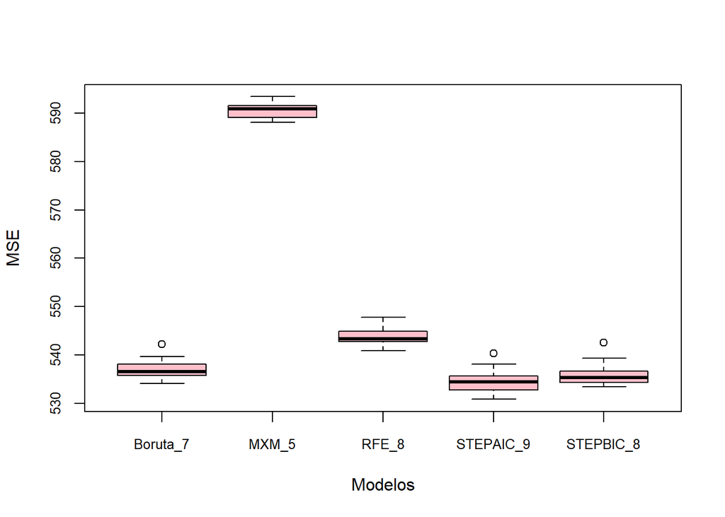

```r
medias5$modelo="RFE_8"

union1<-rbind(medias1,medias2,medias3,medias4,medias5)

par(cex.axis=0.8)
boxplot(data=union1,col="pink",error~modelo, xlab = "Modelos", ylab = "MSE")
```

## Construcción red neuronal

Una vez elegidas las variables que participarán en la construcción del modelo, procederemos a encontrar los mejores parámetros de la red neuronal, primero sin early stopping.

### Calculo de nodos.

7 variables, 1338 obs, con 30 obs por parámetro, usando la siguiente fórmula:

Número de parámetros = h(k+1)+h+1

donde h= número de nodos ocultos, k=número de nodos input

### Túneo de parámetros

Una red neuronal cuenta con 3 básicos parámetros en su construcción, el primero es el número de **nodos ocultos** en la red, el segundo es el **learning rate** el cuál es la velocidad a la que el algoritmo converge a las ponderaciones óptimas de sus pesos y por último el **número de interacciones** el cuál nos permite cuidar el sobreajuste del modelo.

Analizaremos los resultados del modelo de acuerdo a los siguientes rangos de parámetros:

- Nodos ocultos:

```r
data2<-model_data[,c(var_boruta,"charges_sqr")]

control<-trainControl(method = "cv",
                      number=4,savePredictions = "all")

set.seed(123)
nnetgrid <-  expand.grid(size=c(4,5,8,10),decay=c(0.1,0.01,0.001,.0001),bag=F)
completo<-data.frame()
listaiter<-c(10,20,50,100,200,300,500)

for (iter in listaiter)
{
  rednnet<- train(charges_sqr~.,
                  data=data2,
                  method="avNNet",linout = TRUE,maxit=iter,
                  trControl=control,repeats=5,tuneGrid=nnetgrid,trace=F)
  # Añado la columna del parametro de iteraciones
  rednnet$results$itera<-iter
  # Voy incorporando los resultados a completo
  completo<-rbind(completo,rednnet$results)
}

completo$MSE  <-(completo$RMSE)^2
completo<-completo[order(completo$MSE),]

ggplot(completo, aes(x=factor(itera), y=MSE,
                     color=factor(decay),pch=factor(size))) +
  geom_point(position=position_dodge(width=0.5),size=3)
```

[output not shown]

```r
set.seed(123)
nnetgrid <-  expand.grid(size=c(4,5),decay=c(0.2, 0.1,0.05, 0.01),bag=F)
completo<-data.frame()
listaiter<-c(150, 200,250,300)

for (iter in listaiter)
{
  rednnet<- train(charges_sqr~.,
                  data=data2,
                  method="avNNet",linout = TRUE,maxit=iter,
                  trControl=control,repeats=5,tuneGrid=nnetgrid,trace=F)
  # Añado la columna del parametro de iteraciones
  rednnet$results$itera<-iter
  # Voy incorporando los resultados a completo
  completo<-rbind(completo,rednnet$results)
}

completo$MSE  <-(completo$RMSE)^2
completo<-completo[order(completo$MSE),]

ggplot(completo, aes(x=factor(itera), y=MSE,
                     color=factor(decay),pch=factor(size))) +
  geom_point(position=position_dodge(width=0.5),size=3)
```

[output not shown]

## Resultados

Ahora procederemos a comparar los resultados de cada método previo de regresión lineal con una red sin túneo de hiperparámetros y otra con su debido túneo.

```r
data2<-model_data[,c(var_boruta,"charges_sqr")]
medias6<-cruzadaavnnet(data=data2,
                      vardep="charges_sqr",listconti=var_boruta,listclass=c(""),grupos=4,sinicio=1234,repe=25,repeticiones=5,itera=250,
                       size=c(4),decay=c(0.2))
```

```
##   size decay   bag     RMSE  Rsquared      MAE   RMSESD RsquaredSD     MAESD
## 1    4   0.2 FALSE 19.76378 0.8282752 11.45494 1.376181  0.0275538 0.6518148
```

```r
medias6$modelo="Red_ct"

medias7<-cruzadaavnnet(data=data2,
                      vardep="charges_sqr",listconti=var_boruta,listclass=c(""),grupos=4,sinicio=1234,repe=25,repeticiones=5,itera=50,
                       size=c(4),decay=c(0.01))
```

```
##   size decay   bag     RMSE  Rsquared      MAE   RMSESD RsquaredSD    MAESD
## 1    4  0.01 FALSE 21.82915 0.7944698 14.66414 1.314505 0.02971302 1.092603
```

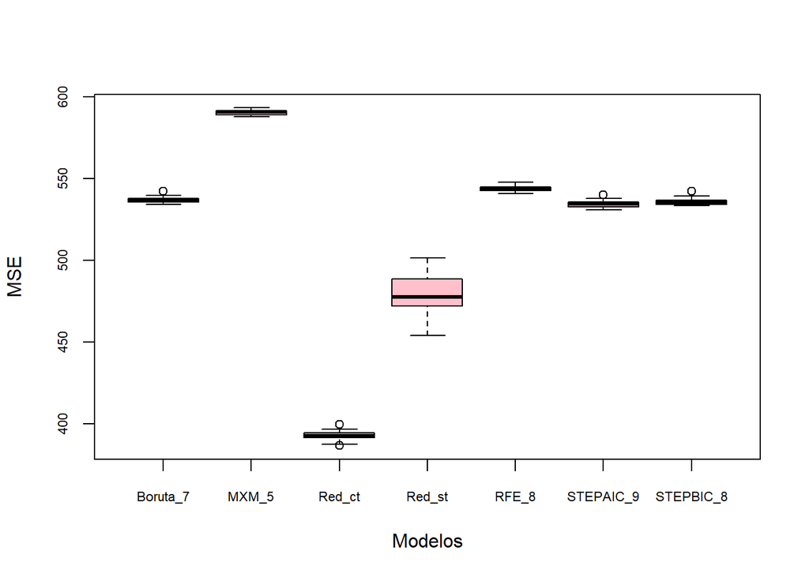

```r
medias7$modelo="Red_st"

union1<-rbind(medias1,medias2,medias3,medias4,medias5,medias6, medias7)

boxplot(data=union1,col="pink",error~modelo, xlab = "Modelos", ylab = "MSE",cex.axis=0.7)
```

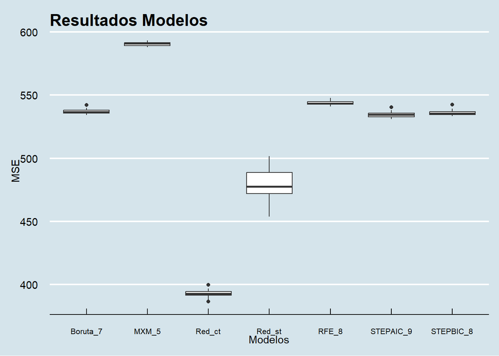

```r
ggplot(union1, aes(x = modelo, y = error)) +
  geom_boxplot() +
  xlab("Modelos") +
  ylab("MSE") +
  ggtitle("Resultados Modelos")+
  theme_economist(base_size = 12, base_family = "sans") +
  theme(axis.text.x = element_text(size = 8))
```

Podemos ver que el modelo **Red_ct** el cual hace alusión al modelo de redes neuronales con túneo en parámetros tiene un mejor resultado que todos los anteriores, incluyendo al mismo modelo de red con diferentes parámetros.